Speed runs are constant-altitude maneuvers during which the airspeed is varied from near minimum to near maximum for the particular flight conditions. Steady wind conditions are needed. The many uses of the speed run will be discussed in more detail in the remainder of this section, but this is a list that summarizes the main benefits of this maneuver:

A level speed run flown in the absence of vertical wind can be used to develop empirical expressions for the angle of attack.

If the temperature is constant or is corrected for horizontal variations along the track, the speed run can be used to determine or check the recovery factor of a temperature probe. For this use, it is preferable to fly the speed run along the direction of the wind, which will usually be parallel to isobars and therefore less likely to encounter temperature variations.

The lag present in temperature sensors can be determined from the difference between recovery temperature measured while accelerating vs. that measured while decelerating.

Consistency of the longitudinal component of the horizontal wind during the speed run is a check on the validity of the measurement of dynamic pressure.

Change in D-value along the track should be linear; if the D-value depends on airspeed also, this indicates a potential error in the static defect that is used to correct the measured ambient pressure.

Similar systematic variation in dew point with airspeed may indicate an error in the measured (or assumed) cavity pressure for the dew point hygrometers or, in the case of the VCSEL hygrometer, an error in the measurement of density in the sensitive aperture of the instrument. Similar checks are useful for trace-gas measurements. Spurious dependence on airspeed in any measurement can be an indicator of some problem needing further investigation.

##### Empirical representation of the angle of attack

This use of speed runs has been discussed in detail in the NCAR Technical Note on [“Characterization of Uncertainty in Measurements of Wind from the NSF/NCAR Gulfstream V Research Aircraft”](http://n2t.net/ark:/85065/d7qr4zqr); see Sect. 5.1 of that document. Figure 19 from that document is repeated here.

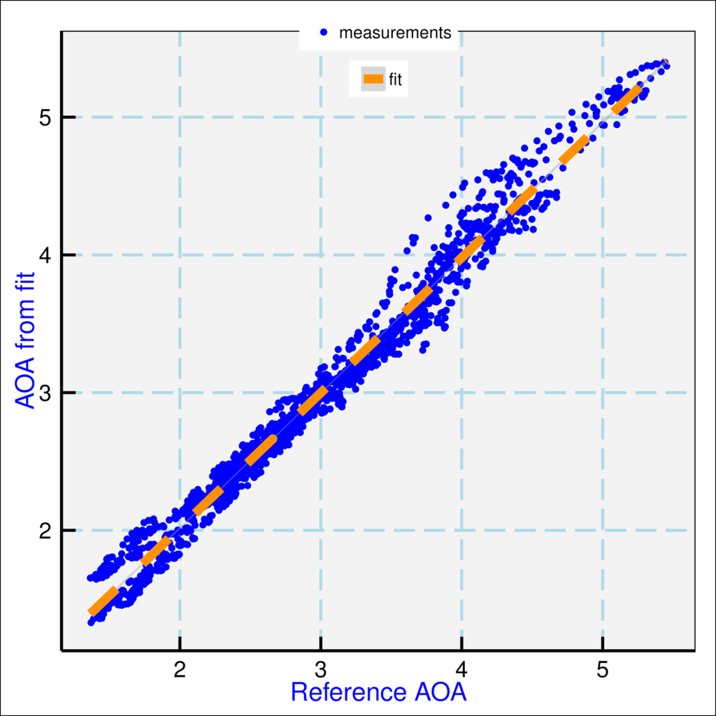

*Figure 1: Measurements from four speed runs from the DEEPWAVE project and the empirical fit to the measurements. The “Reference AOA” is developed in the Technical Note referenced above.*

A different plot is generated by the QA / QC web application under the “angle of attack” item in the drop-down menu. The results from this fit are shown at the top of the plot, but instead three other quantities are plotted: (i) AKRD, the angle of attack in the data file; (ii) AOAREF, the reference angle of attack obtained by assuming that the vertical wind is zero; and (iii) the vertical wind (WIC). If the conditions for the speed run are good (i.e., small vertical wind), the first two should be in good agreement, so significant differences between AKRD and AOAREF indicate either that there is a problem with one of the measurements (most often ADIFR) or that there is significant vertical wind at the location of the speed run. A significant mean vertical wind usually indicates that there may be a problem with AKRD and that the empirical representation of the angle of attack should be reconsidered. See the “Comp-filter AKRD” tab in the “Special” section for an optional approach to improving the representation of AKRD.

#### The recovery factor of temperature sensors

The relationship between the actual ambient temperature (**T** <sub>**a**</sub>) and that measured by a sensor exposed to the airstream (**T** <sub>**r**</sub>) is discussed in the informal [Technical Note on Processing Algorithms](https://drive.google.com/open?id=0B1kIUH45ca5Ab2Z6cld1M1cydjA); see Eq. 20 on p. 36 of that reference, which can be rearranged to this form:

The measured temperature **T** <sub>**r**</sub> is called the “recovery temperature” and, for **α**<sub>**r**</sub> **= 1,** would equal the “total temperature” expected if the air in contact with the sensor were brought completely to rest.

The ambient temperature **T** <sub>**a**</sub> is not known, but it and **α**<sub>**r**</sub> can be determined by plotting and fitting this relationship to the data:

An extensive analysis of 84 speed runs has been used to determine appropriate recovery factors for the HARCO and Rosemount (heated) sensors, as documented in [this memo](https://drive.google.com/open?id=0B1kIUH45ca5AOWlIbGxVcC13SHM). An example is shown in Fig. 2. Similar plots can be generated in the QA application by selecting “recovery factor” from the “type of plot” drop-down menu in the sidebar. This plot always shows the variable RTX, which may be assigned to different temperature sensors in different projects; the assignment used is listed in the title at the top of the plot. In addition to the measurements, the plot shows a fit of (2) to the measurements (the orange line), with coefficients and residual standard deviation as listed at the top of the plot. The second coefficient will normally be between 0.96 and 1.0 and represents the recovery factor. A good fit will usually have a residual standard deviation of 0.2<sup>o</sup> or smaller.

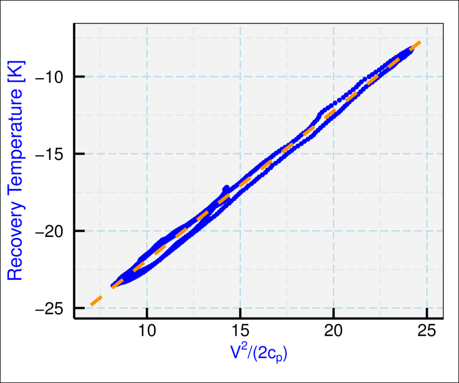

*Figure 2: Fitting a linear line to the expected dependence of the measured recovery temperature on airspeed (V). cp is the specific heat of moist air at constant pressure.*

This plot will often show hysteresis caused by the time response of the sensor. The “set delay” slider can be used to shift the measurements forward (negative values) or backward (positive values) in time to adjust for the response time. The time constant will vary for different sensors and flight conditions, but a value of between -1500 and -2500 ms usually leads to the minimum residual standard deviation. The time constant of the particular probe in use can be estimated by adjusting the slider to minimize the RMS at the top of the plot. There is more discussion of time constants below.

There are some subtle considerations that complicate this analysis, recorded here for reference but not not essential to understanding this data-quality application, so the following points can usually be skipped on first reading:

The calculation of the airspeed **V** depends on the air temperature. The document on Processing Algorithms discusses the method by which airspeed and temperature are obtained by solving simultaneous equations for both. If the recovery factor is changed, the airspeed measurement will also change, so it is not correct to determine a new recovery factor in this way and then use that without consideration of how the change affects the airspeed measurement.

Because the temperature along the flight path is assumed to remain constant, any variation in the temperature will affect the analysis. A linear gradient in temperature can be detected and compensation can be introduced, but it is more difficult to correct for systematic altitude changes such as might occur if the measured pressure varies with airspeed. The avionics package on the aircraft maintains flight on a constant pressure surface, but if there is a static-defect error in the ambient pressure it uses then the aircraft may climb and descend systematically with variations in airspeed, and this would mask a recovery-factor effect. A correction for this effect is developed below.

The dynamic response of temperature sensors is often a first-order exponential response characterized by a single time constant **τ**. The lag in measured temperature affects the analysis of the speed run, and for that reason it is important for this use that the speed run include both accelerating and decelerating segments. Averaging the two legs is helpful, but a better correction is to compensate for the lag by using the ramp response of a first-order sensor because in that case the measurements can simply be shifted forward by the response time to obtain measurements that are corrected for the time lag in sensor response. Because dynamic-heating effects can be 25<sup>∘</sup>C or more, it is important to compensate for the time lag.

#### The time constant of various sensors

The third option in the “type of plot” drop-down menu, “airspeed dependence,” shows the variation with airspeed of the variable selected in the “other variable” selection box. The two colors show, as green, the accelerating part of the speed run and as red the decelerating part. An example is shown below:

The ordinate in Fig. 3 is labeled “shifted” because the time delay specified by the slider has been applied, although in this case the specified value is zero. Any shift is in addition to shifts imposed in data processing to produce the data file. This file can be used in two ways:

Variables can be selected from the “other variable” selection menu to check for airspeed dependence of various measurements. For example, the longitudinal component of the measured wind (UXC) might show a dependence on TASX if there is an error in the measurement of airspeed, so it is useful to check for systematic variation of UXC with airspeed outside a range of about ±2 m/s. Similarly, no systematic variation of humidity or D-value or ATX with airspeed is expected, so a trend in this plot is a suggestion that it may be worth more investigation of that variable.

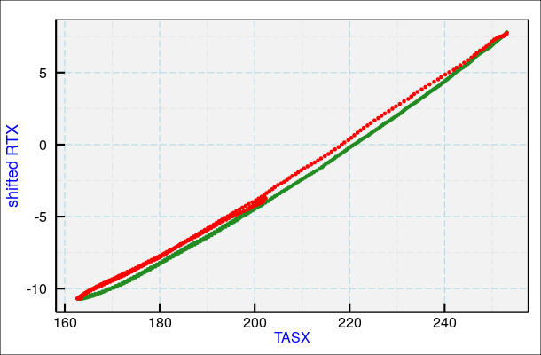

*Fig**ure* *3: An example of the variation in recovery temperature (RTX) as a function of airspeed (TASX) for a speed run. Measurements with airspeed increasing are plotted as green dots and those with decreasing airspeed as red dots. Data from CONTRAST rf08 91651-92702. No time shift has been applied.*

t is possible to estimate the characteristic  
 response time of a sensor by using the time-delay slider to minimize  
 the difference between the accelerating and decelerating branches in  
 a plot like Fig. 3. To support finding an optimal time shift, the  
 residual standard deviation for a cubic polynomial fit to the  
 shifted data is displayed at the top of the plot. For the speed run  
 shown in Fig. 3, selecting a time shift of -2.3 s reduces the  
 residual standard deviation from 0.23 to a minimum at 0.07<sup>o</sup>C, so 2.3 s is the estimated response time of the HARCO temperature probe.